# Determining the contribution of eQTLGen/PsychENCODE eQTLs to GWAS traits

Regina H. Reynolds

UCL

21 January 2022

> Aim: determine the contribution of eQTLGEN/PsychENCODE to neurodegen/neuropysch traits

# 1 Background

eQTL-GWAS bivariate analyses revealed that of the two eQTL datasets, the dataset with the highest number of gene loci (i.e. a gene where eQTLs were detected) was PsychENCODE (eQTLGen, n gene loci = 47; PsychENCODE, n gene loci = 87). In spite of this, the eQTL dataset with highest number of significant bivariate local $r_{g}$ was eQTLGen, irrespective of the stringency of multiple test correctio. While this likely reflects the bias in the selection of the LD blocks, which were weighted towards the AD/PD phenotypes (where we might expect to see a greater association with blood-derived molecular phenotypes), we wanted to determine whether this was also the case more generally. To test this, we chose to run eQTL-GWAS bivariate analyses across an entire chromosome (not genome-wide due to the computational burden associated with this).

# 2 Methods

## 2.1 Deriving loci for eQTL analyses

To reduce the computational burden, we chose to run eQTL-GWAS analyses across only one chromosome. Ideally, this chromosome should have: (i) no or few long-range LD regions in European populations; (ii) overlapping genome-wide signficiant loci from $\geq$ 2 neurodegenerative and $\geq$ 2 neuropsychiatric traits; (iii) a minimum of $\geq$ 2 LD blocks overlapping genome-wide signficiant loci from neurodegenerative or neuropsychiatric traits, with an approximately equal proportion between the two. The number of long-range LD regions in European population were derived from [PMID:31388069](https://pubmed.ncbi.nlm.nih.gov/31388069/).

# 3 Supplementary code

Following section includes any intermediary code used in this `.Rmd`.

# 4 Results

## 4.1 Determining an ideal chromosome candidate

### 4.1.1 Text

- The three chromosomes with the lowest number of genes were 13, 18 and 21 (Figure 4.1a). Of these, 18 was not found to have any long-range LD regions in European populations (Figure 4.1b).
- In terms of overlapping genome-wide signficiant loci, chromosome 18 contained overlapping genome-wide signficiant loci from 2 neurodegenerative (AD, PD) and 2 neuropsychiatric traits (MDD, SCZ). In turn, these overlapped a total of 8 LD blocks (n = 2, neurodegenerative; n = 6, neuropsychiatric; see Figure 4.5 and 4.6 in [01_preparing_inputs_gwas.Rmd](https://rhreynolds.github.io/neurodegen-psych-local-corr/01_preparing_inputs_gwas.html)). Thus, while the proportion of LD blocks overlapping overlapping genome-wide signficiant loci from neurodegenerative or neuropsychiatric traits was not equal, all other criteria were met.

### 4.1.2 Figures

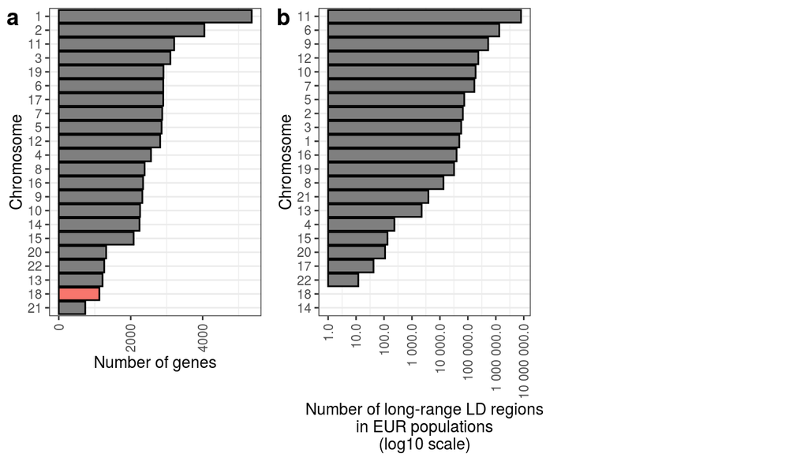

Figure 4.1: (a) Number of genes per chromosome. Chromosome 18 is highlighted by a red fill. (b) Number of long-range LD regions in EUR populations.

```r
ref <- rtracklayer::import("/data/references/ensembl/gtf_gff3/v87/Homo_sapiens.GRCh37.87.gtf")
ref <- ref %>% GenomeInfoDb::keepSeqlevels(c(1:22), pruning.mode = "coarse")
ref <- ref[ref$type == "gene"]

a <-
  ref %>%
  as_tibble() %>%
  dplyr::group_by(seqnames) %>%
  dplyr::count() %>%
  dplyr::arrange(n) %>%
  dplyr::mutate(
    highlight =
      case_when(
        seqnames == "18" ~ "*"
      )
  ) %>%
  ggplot(
    aes(
      x = n,
      y = forcats::fct_reorder(.f = as.factor(seqnames),
                               .x = n,
                               .fun = sum,
                               .desc = FALSE),
      fill = highlight
    )
  ) +
  geom_col(colour = "black") +
  labs(
    x = "Number of genes",
    y = "Chromosome"
  ) +
  theme(
    legend.position = "none"
  )

b <-
  readxl::read_xlsx(
    path = here::here("raw_data", "06_eqtl_chr_check", "park2019_lrld_table1.xlsx"),
    range = "A2:H24"
  ) %>%
  dplyr::select(CHR, EUR) %>%
  dplyr::mutate(
    highlight =
      case_when(
        CHR == "18" ~ "*"
      )
  ) %>%
  ggplot(
    aes(
      x = EUR,
      y = forcats::fct_reorder(.f = as.factor(CHR),
                               .x = EUR,
                               .fun = sum,
                               .desc = FALSE),
      fill = highlight
    )
  ) +
  geom_col(colour = "black") +
  scale_x_log10(n.breaks = 10, labels = scales::number) +
  labs(
    x = "Number of long-range LD regions\nin EUR populations\n(log10 scale)",
    y = "Chromosome"
  ) +
  theme(
    legend.position = "none"
  )

cowplot::plot_grid(
  a,b,
  labels = letters[1:2],
  nrow = 1,
  align = "h",
  axis = "bt",
  legend = "none"
)
```